# Metabolites | Free Full-Text | Influence of Genetic West African Ancestry on Metabolomics among Hypertensive Patients

Metabolites

[Journals](https://www.mdpi.com/about/journals)

[Metabolites](https://www.mdpi.com/journal/metabolites)

[Volume 12](https://www.mdpi.com/2218-1989/12)

[Issue 9](https://www.mdpi.com/2218-1989/12/9)

10.3390/metabo12090783

[figure not shown]

- Academic Editors

[figure not shown]

  Monika Kubacka

[figure not shown]

  Magdalena Kotańska

[figure not shown]

- Table of Contents

0

0

Comment

*first_page*

*settings*

Open AccessArticle

# Influence of Genetic West African Ancestry on Metabolomics among Hypertensive Patients

by

[figure not shown]

Mai Mehanna

<sup>1</sup>

[figure not shown]

,

[figure not shown]

Caitrin W. McDonough

<sup>1</sup>,

[figure not shown]

Steven M. Smith

<sup>1,2</sup>

[figure not shown]

,

[figure not shown]

Yan Gong

<sup>1</sup>

[figure not shown]

,

[figure not shown]

John G. Gums

<sup>1</sup>

[figure not shown]

,

[figure not shown]

Arlene B. Chapman

<sup>3</sup>,

[figure not shown]

Julie A. Johnson

<sup>1</sup>

[figure not shown]

and

[figure not shown]

Rhonda M. Cooper-DeHoff

<sup>1,*</sup>

[figure not shown]

<sup>1</sup>

Department of Pharmacotherapy and Translational Research and Center for Pharmacogenomics and Precision Medicine, College of Pharmacy, University of Florida, Gainesville, FL 32610, USA

<sup>2</sup>

Department of Pharmaceutical Outcomes & Policy, College of Pharmacy, University of Florida, Gainesville, FL 32610, USA

<sup>3</sup>

Department of Medicine, University of Chicago, Chicago, IL 60637, USA

Author to whom correspondence should be addressed.

*Metabolites* **2022**, *12*(9), 783; https://doi.org/10.3390/metabo12090783

Received: 28 July 2022 / Revised: 18 August 2022 / Accepted: 20 August 2022 / Published: 24 August 2022

(This article belongs to the Special Issue [Altered Metabolism Associated with Hypertension—a New Option for Drug Therapy?](https://www.mdpi.com/journal/metabolites/special_issues/metabolism_hypertension_drug))

Download

Browse Figures

[Versions Notes](https://www.mdpi.com/2218-1989/12/9/783/notes)

Keywords:

[African ancestry](https://www.mdpi.com/search?q=African%20ancestry); metabolomics; hypertension; [blood pressure](https://www.mdpi.com/search?q=blood%20pressure)

## 1. Introduction

Overall, Black individuals with hypertension (HTN) have a disease that is more severe and resistant to antihypertensive treatment, poorer blood pressure (BP) control, higher rates of target organ damage and higher mortality rates compared to White individuals with HTN [1,2]. Evidence also suggests that Black patients achieve a better BP response to diuretics and calcium channel blockers, whereas White patients respond better to β-blockers, angiotensin-converting enzyme (ACE) inhibitors and angiotensin II receptor blockers (ARBs) [3]. The mechanisms underlying these racial disparities in HTN and BP response remain poorly understood.

Hypertension is a complex disease with several heterogeneous pathophysiological pathways. These pathways are believed to be regulated by complex interactions between genetic and environmental factors [4,5,6]. Over 1000 genetic loci associated with BP have been previously identified from numerous genome-wide association studies, with some linked to environmental factors such as obesity, sedentary hours, diet, smoking status and alcohol intake [5,6,7,8]. Metabolomics, the study of the intermediates or products of metabolism within cells, is an emerging promising tool that can reflect both genetic and environmental factors, thus enriching our understanding of the dynamic complex metabolic pathways underlying a disease [9]. Over the past few years, numerous studies have shown that various metabolites and metabolic pathways, including fatty acids, phospholipids and metabolites involved in leucine, isoleucine and valine metabolism; tryptophan metabolism; glycine, serine and threonine metabolism; and the urea cycle, are altered in patients with HTN compared to healthy controls [10,11,12,13,14,15,16,17,18]. Additionally, several studies have shed light on metabolic changes that occur upon treatment with antihypertensive agents [19,20,21,22,23,24]. Among these metabolic changes, treatment with thiazide diuretics, β-blockers and calcium channel blockers was associated with increased uric acid and urea cycle metabolites, decreased levels of medium- and long-chain fatty acids, and decreased levels of acyl-carnitines and hexadecanedioate, respectively [19,20,21,23]. Collectively, these studies provide insights on the diverse pathways underlying HTN but have not significantly improved our understanding of HTN racial disparities.

Only a few studies with relatively small sample sizes have explored metabolomic differences between healthy Black and White individuals or between Black and White patients with HTN [25,26,27]. However, these studies reported self- or investigator-defined race, which is a social rather than biological construct and is confounded by racism, socioeconomic inequality and environmental disparities [28,29]. Because US Black and White individuals represent a mixture of West African and European geographic ancestries with diverse frequencies, the biological mechanisms that contribute to racial disparities in HTN may be better informed by using genetically defined ancestry [29,30]. In this study, we aimed to identify the differential metabolites and metabolic clusters between US hypertensive participants with genetic West African ancestry (GWAA) < 45% and those with GWAA ≥ 45%, followed by replication in an independent cohort. We also sought to further test the association between the metabolites within the replicated clusters and the proportion of GWAA among hypertensive patients with GWAA ≥ 45% to assess whether the metabolomic differences are driven by ancestral biological disparities or by other extrinsic and social factors that are different between the two ancestry groups.

## 2. Results

#### 2.1. Study Population

The analysis in the current study included baseline data from participants enrolled in the Pharmacogenomic Evaluation of Antihypertensive Responses (PEAR) trial (discovery cohort) and in the PEAR-2 trial (replication cohort). For the 125 participants enrolled in both studies, only data from PEAR-2 were included (Figure S1a). In addition, for PEAR-2 participants who had baseline metabolomics data at two different time points (pre-metoprolol (first time point) and pre-chlorthalidone (second time point)), only the pre-metoprolol data were included in the replication analysis. A total of 633 participants from PEAR and a total of 411 participants from PEAR-2 were included (Figure S1b). The baseline characteristics of the participants from both cohorts are presented in Table 1. Overall, the participants were about 50 years old, on average; a majority were overweight or obese with a mean body mass index of about 31 kg/m<sup>2</sup>, and 50% were women. In both trials, participants with GWAA ≥ 45% had lower baseline plasma renin activity (PRA) compared to those with GWAA < 45%, consistent with the prior literature [3,31,32]. Among PEAR and PEAR-2 participants with lower GWAA, the median GWAA proportion was 1.6% (interquartile range (IQR), 1–3.5%). Of these participants, 2.6% self-identified as Asian or another race. In contrast, among PEAR and PEAR-2 participants with higher GWAA, the median GWAA proportion was 85.1% (IQR, 79–90.6%). Of these participants, 2.3% self-identified as White or other (Figure S2a–d).

**Table 1.** Baseline characteristics of participants included from PEAR and PEAR-2 studies.

[figure not shown]

#### 2.2. Data Processing and Quality Control of PEAR Metabolomics Data

Of the 1223 metabolites (971 known and 252 unknown) detected in the PEAR plasma samples at baseline, 337 metabolites were excluded, including xenobiotics (n = 191) and metabolites with >60% missing data (n = 146). The remaining 886 metabolites (699 known and 187 unknown) were included in the quality control (QC) steps and final analyses. Principal Component Analysis (PCA) and Standard Euclidean Distance (SED), performed for QC, indicated that 25 participants were considered outliers based on their metabolomics data (Figure S3). The Bland–Altman (BA) method flagged 24 metabolites, each having >5% of the values as outliers (Table S1). Lastly, the top 10% of metabolites with the largest Coefficient of Variation (CV) values (metabolites with the highest variability among PEAR participants) (n = 36) were flagged (Table S2). More details on the data processing and QC work are illustrated in Supplementary Material.

#### 2.3. Untargeted Metabolomics Analysis

Partial least-squares discriminant analysis (PLS-DA) using the baseline log-transformed levels of the 886 metabolites showed a separation between PEAR participants with GWAA < 45% and those with GWAA ≥ 45% (Figure S4). The overall study results are summarized in Figure 1. The baseline log-transformed levels of each of the 886 metabolites were compared between PEAR participants with lower GWAA and those with higher GWAA. Based on a false discovery rate (FDR) < 0.2, a total of 423 metabolites were significantly different between the two ancestry groups (Table S3). Of those, 209 metabolites were more abundant in participants with higher vs. lower GWAA, mainly including amino acids involved in tyrosine metabolism, as well as plasmalogens and lipids involved in bile acid metabolism. Conversely, 214 metabolites were more abundant in participants with lower vs. higher GWAA, mainly including amino acids involved in glutathione metabolism, lysine metabolism and methionine, cysteine, S-Adenosylmethionine (SAM) and taurine metabolism, as well as diacylglycerols and acyl carnitines. Similar results were obtained after conducting a sensitivity analysis, excluding PEAR participants flagged by PCA (n = 2), SED (n = 21) and both PCA and SED (n = 2) QC steps.

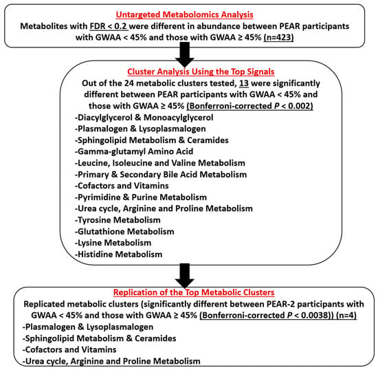

**Figure 1.** Chart showing the flow of the study results. Abbreviations: FDR, false discovery rate; PEAR, Pharmacogenomic Evaluation of Antihypertensive Responses; GWAA, African ancestry.

#### 2.4. Cluster Analysis Using the Top Signals

Because many of the 423 metabolites identified in the screening phase were highly correlated, we grouped metabolites into metabolic clusters using the Modulated Modularity Clustering (MMC) approach and based on the biological pathways to which these metabolites were mapped. Of the 423 metabolites, a total of 70 (unknown metabolites (n = 45), known unclassified metabolites (n = 20), an amino acid involved in guanidino and acetamido metabolism (n = 1), amino acids involved in polyamine metabolism (n = 2) and energy metabolites (n = 2)) were excluded since they did not cluster well with any of the known classified metabolites. The remaining 353 metabolites were used to create a total of 24 metabolic clusters (Table S4).

Cluster analysis using multivariable linear regression showed that 13 of the 24 metabolic clusters achieved Bonferroni-corrected p < 0.002. The principal component 1 (PC1) values for each of these 13 metabolic clusters were significantly different between PEAR participants with lower GWAA and those with higher GWAA. Although all 13 clusters were moved forward to the replication phase, the PC1 distribution of four clusters was either highly skewed or bimodal and was flagged. The remaining nine significant non-flagged clusters were diacylglycerol and monoacylglycerol, plasmalogen and lysoplasmalogen, sphingolipid metabolism and ceramides, gamma-glutamyl amino acid, primary and secondary bile acid metabolism, cofactors and vitamins, pyrimidine and purine metabolism, glutathione metabolism and histidine metabolism (Table 2 and Figure 2).

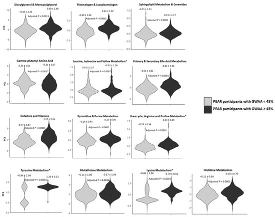

**Figure 2.** Violin plots comparing PC1 values of each of the 13 significant metabolic clusters between PEAR participants with GWAA < 45% and those with GWAA ≥ 45%. Gray bars represent PEAR participants with GWAA < 45%, whereas the black bars represent PEAR participants with GWAA ≥ 45%. The adjusted p-values (Bonferroni-corrected) were calculated using multivariable linear regression models adjusted for age, sex, recruitment site, baseline log-transformed PRA and batch effect. * Metabolic clusters with highly skewed or bimodal PC1 distribution (n = 4) (flagged): leucine, isoleucine and valine metabolism; urea cycle/arginine and proline metabolism; tyrosine metabolism and lysine metabolism. Abbreviations: PC, principal component; PEAR, Pharmacogenomic Evaluation of Antihypertensive Responses; GWAA, Genetic West African ancestry.

**Table 2.** Results of the cluster analysis conducted using PEAR discovery cohort on the 24 metabolic clusters.

[figure not shown]

#### 2.5. Replication of the Top Metabolic Clusters

Of the 13 metabolic clusters tested for replication in PEAR-2, 4 were successfully replicated. These clusters were plasmalogen and lysoplasmalogen, sphingolipid metabolism and ceramides, cofactors and vitamins and urea cycle–arginine–proline metabolism. The cluster analysis showed that the PC1 values for each of these four metabolic clusters were significantly different between PEAR-2 participants with lower GWAA and those with higher GWAA (Bonferroni-corrected p < 0.0038) (Table 3 and Figure 3). In addition, at least 90% of the metabolites included in each of these four replicated clusters had the same direction of effect as in the PEAR study (Table S5).

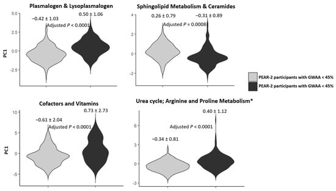

**Figure 3.** Violin plots comparing PC1 values of each of the 4 replicated metabolic clusters between PEAR-2 participants with GWAA < 45% and those with GWAA ≥ 45%. Gray bars represent PEAR participants with GWAA < 45%, whereas black bars represent PEAR participants with GWAA ≥ 45%. The adjusted p-values (Bonferroni-corrected) were calculated using multivariable linear regression models adjusted for age, sex, recruitment site, baseline log-transformed PRA and batch effect. * The metabolic cluster (urea cycle; arginine and proline metabolism) with highly skewed PC1 distribution was flagged. Abbreviations: PC, principal component; PEAR, Pharmacogenomic Evaluation of Antihypertensive Responses; GWAA, Genetic West African ancestry.

**Table 3.** Results of the cluster analysis conducted using the PEAR-2 replication cohort on the 13 metabolic clusters.

[figure not shown]

Only the urea cycle–arginine–proline metabolic cluster was flagged due to its highly skewed PC1 distribution. However, a sensitivity analysis using the Mann–Whitney U test showed that the PC1 values for this cluster were also significantly different between PEAR-2 participants with lower GWAA and those with higher GWAA (p < 0.0001). Within the replicated clusters, a total of six metabolites were flagged by the BA and CV QC steps. The details of these results are presented in Supplementary Material.

Within the plasmalogen and lysoplasmalogen cluster, 14 of 15 metabolites were more abundant in hypertensive participants with higher vs. lower GWAA in both PEAR and PEAR-2 (Table S5). Although not statistically significant, our estimates show that as the proportion of GWAA among PEAR and PEAR-2 participants with higher GWAA increases, the levels of 11 of these metabolites also increase (Table S6).

Within the sphingolipid metabolism and ceramides cluster, 13 of 14 metabolites had the same direction of effect in both PEAR studies: 7 were higher in hypertensive participants with higher GWAA, whereas 6 were higher in those with lower GWAA (Table S5).

Within the cofactors and vitamins cluster, 20 of 22 metabolites had the same direction of effect in both PEAR studies. Participants with lower GWAA had higher levels of the three metabolites involved in tocopherol metabolism and the three metabolites involved in nicotinate and nicotinamide metabolism (Table S5 and Figure S5). In contrast, participants with higher GWAA had higher levels of the three sulfate isomers of piperine (Table S5).

Within the urea cycle–arginine–proline metabolism cluster, all 12 metabolites had the same direction of effect in both PEAR studies. This included arginine, homoarginine, hydroxyproline and homocitrulline, which were all more abundant in participants with higher GWAA than those with lower GWAA (Table S5 and Figure S6).

## 3. Discussion

Racial disparities in HTN are believed to be multifactorial, involving genetic factors, psychosocial stressors, socioeconomic status and other structural or environmental factors [33]. To our knowledge, this is the first study undertaken to explore the metabolomic differences between hypertensive participants with lower and higher GWAA, with findings that might reflect some of these underlying factors. Using data from two independent cohorts, we were able to identify and replicate four metabolic clusters (plasmalogen and lysoplasmalogen, sphingolipid metabolism and ceramides, cofactors and vitamins and urea cycle–arginine–proline metabolism) that differed based on GWAA. We found distinct cluster profiles by comparing hypertensive participants with lower vs. higher GWAA, as well as differences in the abundance of metabolites within each cluster.

Our data showed that the plasmalogen and lysoplasmalogen cluster was significantly different between hypertensive participants with lower and those with higher GWAA in both PEAR and PEAR-2. Within that cluster, 14 of 15 metabolites were present at higher levels in participants with higher GWAA compared to those with lower GWAA. Plasmalogens are a class of membrane glycerophospholipids, which represent up to 20% of total phospholipids in humans. Lysoplasmalogens are produced via degradation of plasmalogens by the action of phospholipase A2 [34]. In a prior study investigating metabolite differences after a dietary intervention, several of these lipids, including 1-(1-enyl-palmitoyl)-2-arachidonoyl-GPC (P-16:0/20:4)*, 1-(1-enyl-palmitoyl)-2-linoleoyl-GPE (P-16:0/18:2)* and 1-(1-enyl-stearoyl)-2-linoleoyl-GPE (P-18:0/18:2)* (all were more abundant in participants with higher vs. lower GWAA in our study), were found to be lower among participants randomly assigned to the Dietary Approaches to Stop Hypertension (DASH) diet compared to those randomly assigned to the control diet [35]. In addition, Spears et al. showed that decreased circulating plasmalogens in mice were associated with decreased BP [36]. Additionally, in a population-based Chinese cohort, two plasmalogens within this cluster, 1-(1-enyl-oleoyl)-GPE (P-18:1)* and 1-(1-enylpalmitoyl)-GPE (P-16:0), were shown to be involved in BP regulation [37]. These studies suggest a potential positive relationship between these metabolites and BP. We also found that most of the metabolites within the plasmalogen and lysoplasmalogen cluster were positively associated with the proportion of GWAA, which might indicate potential biological differences that complement other differential environmental or social factors between the two ancestry groups.

We demonstrated that the sphingolipid metabolism and ceramides cluster was significantly distinct between hypertensive participants with lower GWAA and those with higher GWAA in both PEAR studies. Among healthy subjects, Hammad et al. showed that African Americans had higher levels of most sphingomyelins and ceramides tested compared to White Americans [38]. Sphingolipids and ceramides were found to be involved in the regulation of vascular contractility via regulation of nitric oxide (NO) and have also been positively linked to HTN, resistant HTN and BP in several previous studies [24,37,39,40,41]. In addition, among the metabolites within our replicated sphingolipid metabolism and ceramides cluster, sphingomyelin (d18:2/24:2)*, sphingomyelin (d18:1/21:0, d17:1/22:0, d16:1/23:0)*, sphingomyelin (d18:2/14:0, d18:1/14:1)*, sphingomyelin (d18:2/16:0, d18:1/16:1)* and sphingomyelin (d18:1/14:0, d16:1/16:0)* have been previously significantly positively associated with BP [37]. Additionally, we and others previously demonstrated that N24:2 sphingomyelin, sphingosine 1-phosphate and sphingomyelin C24:1 were associated with BP response to the thiazide diuretic hydrochlorothiazide (HCTZ) [21,42,43]. These studies reflect the relevance of these lipids to HTN pathophysiology and HCTZ BP response.

Moreover, our data indicate that the cofactors and vitamins cluster was significantly different between hypertensive participants with lower GWAA and those with higher GWAA in both PEAR cohorts. Within that cluster, three of four metabolites tested within the tocopherol (vitamin E) metabolic pathway (including alpha-tocopherol) and all three metabolites tested within the nicotinate and nicotinamide (vitamin B3) metabolic pathway were higher in participants with lower GWAA than in those with higher GWAA. Consistently, data from the National Health and Nutrition Examination Survey (NHANES) (1999–2000) showed that White Americans had significantly higher levels of serum alpha-tocopherol compared to African Americans [44]. Previous animal and human studies also showed that the metabolites within these two pathways were inversely correlated with HTN, BP and cardiovascular disease (CVD)-related mortality [16,45,46,47,48,49]. Alpha-tocopherol has been previously shown to be associated with a decreased risk of incident HTN as well as overall mortality [16,46]. In addition, nicotinamide resulted in a decrease in BP in endothelial nitric oxide synthase (eNOS)-null mice, which might indicate its potential beneficial effect in hypertensive patients with impaired eNOS [48]. Further studies are warranted to assess whether these metabolites contribute to racial disparities in HTN severity and outcomes, as well as in antihypertensive response [1]. Interestingly, our data suggest that alpha-tocopherol levels were also negatively associated with the proportion of GWAA, which might reflect biological differences between the two ancestry groups. In line with this finding, several genetic variants (located within genes involved in vitamin E uptake and catabolism) that have been associated with lower alpha-tocopherol levels have higher frequencies in African Americans than in Europeans [50,51,52].

We also replicated the urea cycle–arginine–proline metabolism cluster. Participants with higher GWAA had a higher abundance of arginine and homoarginine compared to those with lower GWAA. Previous studies yielded inconsistent results on the levels of these metabolites in Black vs. White participants [53,54,55]. Both arginine and homoarginine increase the bioavailability of the vasorelaxant NO. However, the literature shows controversial findings on the beneficial effects of arginine on BP and other CVD risk factors [10,14,54,56,57,58,59]. Additionally, homoarginine was previously associated with an increased risk of HTN, dyslipidemia, insulin resistance and elevated BP [54,60]. Due to the controversy of the relationship of arginine and homoarginine with HTN, BP and CVD, the role of these metabolites in HTN pathophysiology remains unclear, and future studies are warranted.

Within the replicated urea cycle cluster, we found that participants with higher GWAA had a higher abundance of hydroxyproline and homocitrulline compared to those with lower GWAA. Consistent with our findings, Mels et al. showed that Black participants had higher hydroxyproline levels compared with White participants [26]. Another study demonstrated that methylation of the upstream gene to hydroxyproline (prolyl 4-hydroxylase subunit alpha 3 or P4HA3) was associated with systolic and diastolic BP in South Asians [61]. Moreover, studies demonstrated that hydroxyproline was linked to heart failure in patients with HTN, and that homocitrulline was associated with an increased risk of CVD, renal damage and death [62,63,64,65,66]. We previously showed that increased hydroxyproline levels upon treatment with the β-blocker atenolol were associated with poorer BP response in Black individuals but not White individuals with HTN [23,67]. Future studies are necessary to assess whether these metabolites contribute to racial disparities in HTN severity and outcomes, as well as in BP response.

Our study has several strengths. First, the results were generated using data from two independent cohorts of highly phenotyped patients with HTN who did not have other chronic diseases, thus reducing potential confounding effects on our findings. We also used genetically defined ancestry, rather than using self-identified race, which may be a more accurate reflection of ancestry. Our study also has several limitations. First is the unavailability of several PEAR metabolic signals in the PEAR-2 dataset. This might have resulted in missing important metabolomic differences between the two ancestry groups. Second, the sample size of PEAR and PEAR-2 participants with higher GWAA was relatively small, which might have limited our power to identify the biological relevance of the metabolites identified within replicated clusters. Third, we identified several unnamed metabolites within our replicated clusters that have unknown implications, and thus, we are not currently able to speculate on insights pertaining to these metabolites.

## 4. Materials and Methods

#### 4.1. Study Design and Participants

The primary analysis in the current study included baseline data from participants recruited as part of the PEAR clinical trial (discovery cohort) and as part of the PEAR-2 trial (replication cohort). Both PEAR studies were prospective, multicenter clinical trials conducted in accordance with the Declaration of Helsinki. The protocols were approved by the institutional review boards at all participating US sites (University of Florida in Gainesville, FL; Mayo Clinic in Rochester, MN; and Emory University in Atlanta, GA). All participants provided voluntary written informed consent prior to participation. Further details about study designs are described below and in Supplementary Material.

PEAR and PEAR-2 have been previously described in detail [68,69]. Briefly, adult participants of any race and ethnicity with uncomplicated mild-to-moderate primary HTN were recruited. Participants with secondary HTN, isolated systolic HTN, CVD, diabetes mellitus, or renal or hepatic dysfunction were excluded. Pregnant and lactating women were also excluded. For participants receiving HTN treatment at the time of enrollment, all antihypertensive drugs were discontinued prior to treatment with the protocol-specified antihypertensive drugs (β-blockers and thiazide diuretics), with a washout period of 4–6 weeks. In both trials, pre- and post-treatment BPs were measured, and blood samples were collected at baseline to conduct genotyping and global metabolomics profiling.

PEAR was a randomized, open-label clinical trial (clinicaltrials.gov identifier: NCT00246519), where participants were randomly assigned to either atenolol (β-blocker) followed by HCTZ (thiazide diuretic) as an add-on therapy or HCTZ followed by atenolol as an add-on therapy. PEAR-2 was an open-label, sequential clinical trial (clinicaltrials.gov identifier: NCT01203852), where participants were sequentially treated with metoprolol (a β-blocker) monotherapy, followed by chlorthalidone (a thiazide-like diuretic) monotherapy, with a 4-week washout in between.

#### 4.2. Genotyping and Estimation of GWAA

In PEAR, DNA samples were genotyped for ≈1 million single nucleotide polymorphisms (SNPs) using the Illumina Human Omni 1MQuad BeadChip (Illumina, San Diego, CA, USA), and DNA samples from PEAR-2 participants were genotyped for ≈2.5 million SNPs using the Illumina Human Omni2.5S BeadChip (Illumina) [70]. The QC procedures conducted on the genetic data from both studies have been previously described [71].

The global proportion of West GWAA for each PEAR and PEAR-2 participant was estimated using genetic ancestry-informative markers (AIMs), which are defined as SNPs that have largely different frequencies between populations. Evidence suggests that using as few as 64 AIMs can accurately estimate individual genetic ancestry [72]. In this study, we used genome-wide directly genotyped data of 84 AIMs, selected from two sets of previously validated AIMs [72,73]. Our AIMs were selected based on at least 30% difference in allele frequency between the African and the European populations and on the availability of their genotype data in PEAR and PEAR-2 (Table S7) [74]. Using the genotype data of 90 Yoruba individuals (representing GWAA) and 90 European American individuals from the HapMap database, who served as the parental reference populations, the global proportion of GWAA was estimated for each PEAR and PEAR-2 participant [30] using STRUCTURE software with the parameter K set to two populations [75]. The software models the probability of the observed genotypes given the individual ancestry proportions and the ancestral population allele frequencies using traditional Bayesian methods [76].

#### 4.3. Untargeted Metabolomics Profiling

Baseline fasting plasma samples from PEAR and PEAR-2 participants were used to perform untargeted/global metabolomics profiling by Metabolon, Inc., Durham, NC, USA, using ultrahigh-performance liquid chromatography–tandem mass spectroscopy (UPLC-MS/MS) (Waters, Milford, MA, USA) [77]. This process has been previously described in detail [43]. Briefly, samples were divided into aliquots and stored at −80° Celsius until processed. At the time of the analysis, an aliquot was thawed, extracted and centrifuged to recover the metabolites. The extract was then divided into five aliquots. Two aliquots were analyzed by two separate reverse phases (RP)/UPLC-MS/MS with positive ion mode electrospray ionization (ESI); one was chromatographically optimized for more hydrophilic compounds, and the other was optimized for more hydrophobic compounds. The third aliquot was analyzed by RP/UPLC-MS/MS with negative ion mode ESI. The fourth aliquot was analyzed using hydrophilic interaction liquid chromatography (HILIC)/UPLC-MS/MS with negative ion mode ESI. The fifth aliquot was reserved for backup. The peaks of each metabolite were quantified using the area under the curve. Metabolites were then identified by comparison to library entries of purified authenticated standards or recurrent unknown entries. All molecules present in this library have information on the retention time/index (RI), mass-to-charge ratio (m/z) and chromatographic data. Each metabolite was corrected in run-day blocks by normalizing each data point proportionately.

#### 4.4. Data Processing and QC of PEAR Metabolomics Data

MetaboAnalyst 5.0, an open-source R-based program for metabolomics, and Galaxy Southeast Center for Integrated Metabolomics (SECIM) tools were used to perform data processing and QC [78,79]. This work is presented in detail in Supplementary Material. In brief, all xenobiotics and metabolites with greater than 60% missingness were excluded. Non-imputed data of the remaining metabolites were included in the QC steps and in the main analysis. Imputation was conducted using the K-nearest neighbor (KNN) algorithm only to perform the PCA, which was used to identify clustering or extreme outliers among PEAR participants based on their metabolomics data. Potential outliers were also identified using SED values. The concordance of the metabolomics data between pairs of PEAR participants within each subgroup was assessed using the BA method [80]. In addition, CV was calculated to assess the consistency of metabolites across participants.

#### 4.5. Statistical Analyses

Baseline characteristics of the PEAR and PEAR-2 participants are presented using descriptive statistics. Data for continuous variables are summarized as means with standard deviations (SDs), except for baseline PRA and the proportion of GWAA, which were not normally distributed and are instead summarized as median with IQR. Normally distributed continuous variables were compared between participants with GWAA < 45% and those with GWAA ≥ 45% using the independent t-test, whereas the non-normally distributed variables were compared using the Mann–Whitney U test. Data for categorical variables were summarized as numbers and percentages and were compared between the two ancestry groups using the Chi-square test. Metabolomics data in the PEAR studies were not normally distributed. Therefore, log-transformed metabolomics data were used in all analyses. In this study, we used a 3-phase analytic approach, as outlined below. All statistical analyses were conducted in SAS (version 9.4; SAS Institute Inc., Cary, NC, USA) and R Statistical Software (Foundation for Statistical Computing, Vienna, Austria).

#### 4.5.1. Untargeted Metabolomics Analysis (Screening Phase)

After data processing, using the baseline log-transformed levels of the remaining metabolites, multivariate analysis was performed using PLS-DA to detect whether there is a separation between PEAR participants with GWAA < 45% and those with GWAA ≥ 45%. We used the 45% GWAA cutoff based on two criteria: (1) based on prior published work that studied the genetic ancestry of over 5000 self-reported US African Americans and found that ~90% of that population had African ancestry of 44–46% [81] and (2) based on our PEAR data, which showed that the highest GWAA proportion among the PCA-identified White participants was about 40%. Then, the baseline log-transformed levels (in terms of raw area counts, non-imputed data) of each metabolite included in the analysis were compared between PEAR participants with GWAA < 45% and those with GWAA ≥ 45%. This comparison was conducted using multivariable linear regression models adjusted for sex, age, recruitment site, baseline log-transformed PRA and batch effect. Missing values for each tested metabolite were ignored, resulting in a different sample size for each metabolite. Metabolites with FDR < 0.2 were identified and moved forward to the next phase. We used a less stringent FDR threshold since this was a screening phase, in which we were more concerned about type II rather than type I error. A sensitivity analysis was also conducted, excluding PEAR participants flagged by the PCA and SED QC steps. Metabolites flagged by the BA or CV QC steps were included in the analyses but planned to be further investigated if any of them were included within any of the replicated metabolic clusters.

#### 4.5.3. Replication Phase of the Top Metabolic Cluster(s)

Additionally, for the replicated metabolic clusters, we tested whether these metabolomic differences are mainly driven by ancestral biological disparities or by other extrinsic and social factors that are different between the two ancestry groups. To do so, we tested the association between each metabolite within each replicated cluster and the proportion of GWAA among both PEAR and PEAR-2 participants with higher GWAA using multivariable linear regression, adjusted for sex, age, recruitment site, baseline log-transformed PRA and batch effect. We restricted this analysis to participants with higher GWAA because the proportion of GWAA was only normally distributed in these participants (Figure S2).

## 5. Conclusions

In conclusion, our study sheds light on several metabolites and metabolic pathways that are significantly distinct between US hypertensive patients with lower GWAA and those with higher GWAA. The prior literature along with our novel findings indicates that many of these metabolomic differences might be involved in the mechanisms underlying HTN. Further studies on the identified metabolites and metabolic pathways are needed to confirm our findings and to explore their potential role in the underlying observed racial disparities in HTN severity, outcomes and BP response. A better understanding of these disparities might result in a more effective personalization of antihypertensive treatment for patients with lower vs. higher GWAA. This could help in eliminating the racial disparities currently seen in HTN, leading to better BP control and a reduction in CVD.

## Supplementary Materials

The following supporting information can be downloaded at: https://www.mdpi.com/article/10.3390/metabo12090783/s1. Figure S1: Diagrams showing participants included in this study; Figure S2: Distributions of GWAA proportion among PEAR and PEAR-2 participants with GWAA < 45% and those with GWAA ≥ 45%; Figure S3: PCA scatter plots showing clustering of PEAR participants (n = 633) based on the first three PCs; Figure S4: Partial least-squares discriminant analysis (PLS-DA) of the 886 plasma metabolites in PEAR participants with GWAA < 45% (n = 383) and PEAR participants with GWAA ≥ 45% (n = 250); Table S1: Metabolites flagged by the BA measures and plots in PEAR (n = 24); Table S2: The top 10% of metabolites with the largest CV values in PEAR (n = 36); Table S3: Classifications of the differential 423 metabolites (FDR < 0.2) between PEAR participants with GWAA < 45% and those with GWAA ≥ 45% (screening phase); Table S4: The 24 metabolic clusters created using the 353 PEAR metabolites identified in the screening phase; Table S5: Metabolites within each of the 4 replicated metabolic clusters; Table S6: Metabolites within replicated clusters having the same direction of effect using the proportion of GWAA among PEAR participants with GWAA ≥ 45% (n = 250) and PEAR-2 participants with GWAA ≥ 45% (n = 187); Figure S5: The KEGG nicotinate and nicotinamide metabolic pathway; Figure S6: The KEGG arginine and proline metabolic pathway; Table S7: The 84 AIMs used to estimate the proportion of GWAA for each PEAR and PEAR-2 participant.

## Author Contributions

Conceptualization, M.M., C.W.M. and R.M.C.-D.; formal analysis, M.M.; writing—original draft preparation, M.M.; writing—review and editing, C.W.M., S.M.S., Y.G., J.G.G., A.B.C., J.A.J. and R.M.C.-D.; supervision, R.M.C.-D. All authors have read and agreed to the published version of the manuscript.

## Funding

This study was funded by the National Institute of Health (NIH) Pharmacogenetics Research Network grant U01-GM074492 and the National Center for Advancing Translational Sciences under the award number UL1 TR000064 (University of Florida); UL1 TR000454 (Emory University); and UL1 TR000135 (Mayo Clinic). The Pharmacogenomics Evaluation of Antihypertensive Responses efforts at Mayo Clinic were also supported by funds from Mayo Foundation.

## Institutional Review Board Statement

This study was conducted according to the guidelines of the Declaration of Helsinki and approved by the Institutional Review Boards at all participating sites (University of Florida in Gainesville, FL, USA; Mayo Clinic in Rochester, MN, USA; and Emory University in Atlanta, GA, USA).

## Informed Consent Statement

Written informed consent was obtained from all subjects involved in the study.

## Data Availability Statement

The data presented in this study are available on request from the corresponding author. The data are not publicly available due to ethical and privacy concerns.

## Acknowledgments

We thank the participants, staff and study physicians of PEAR and PEAR-2 studies for their contributions.

## Conflicts of Interest

The authors declare no conflict of interest.

## References

1. Aggarwal, R.; Chiu, N.; Wadhera, R.K.; Moran, A.E.; Raber, I.; Shen, C.; Yeh, R.W.; Kazi, D.S. Racial/Ethnic Disparities in Hypertension Prevalence, Awareness, Treatment, and Control in the United States, 2013 to 2018. Hypertension **2021**, 78, 1719–1726. [Google Scholar] [[CrossRef](https://doi.org/10.1161/HYPERTENSIONAHA.121.17570)] [[PubMed](https://www.ncbi.nlm.nih.gov/pubmed/34365809)]
2. Center for Disease Control and Prevention, National Center for Health Statistics. National Vital Statistics System: Public Use Data File Documentation: Mortality Multiple Cause-of-Death Micro-Data Files. 2020. Available online: https://www.cdc.gov/nchs/data/dvs/Multiple-Cause-Record-Layout-2020.pdf (accessed on 15 June 2022).
3. Brewster, L.M.; Seedat, Y.K. Why do hypertensive patients of African ancestry respond better to calcium blockers and diuretics than to ACE inhibitors and β-adrenergic blockers? A systematic review. BMC Med. **2013**, 11, 141. [Google Scholar] [[CrossRef](https://doi.org/10.1186/1741-7015-11-141)] [[PubMed](https://www.ncbi.nlm.nih.gov/pubmed/23721258)]
4. Harrison, D.G.; Coffman, T.M.; Wilcox, C.S. Pathophysiology of Hypertension: The Mosaic Theory and Beyond. Circ. Res. **2021**, 128, 847–863. [Google Scholar] [[CrossRef](https://doi.org/10.1161/CIRCRESAHA.121.318082)]
5. Evangelou, E.; Warren, H.R.; Mosen-Ansorena, D.; Mifsud, B.; Pazoki, R.; Gao, H.; Ntritsos, G.; Dimou, N.; Cabrera, C.P.; Karaman, I.; et al. Genetic analysis of over 1 million people identifies 535 new loci associated with blood pressure traits. Nat. Genet. **2018**, 50, 1412–1425. [Google Scholar] [[CrossRef](https://doi.org/10.1038/s41588-018-0205-x)] [[PubMed](https://www.ncbi.nlm.nih.gov/pubmed/30224653)]
6. Pazoki, R.; Dehghan, A.; Evangelou, E.; Warren, H.; Gao, H.; Caulfield, M.; Elliott, P.; Tzoulaki, I. Genetic Predisposition to High Blood Pressure and Lifestyle Factors: Associations With Midlife Blood Pressure Levels and Cardiovascular Events. Circulation **2018**, 137, 653–661. [Google Scholar] [[CrossRef](https://doi.org/10.1161/CIRCULATIONAHA.117.030898)] [[PubMed](https://www.ncbi.nlm.nih.gov/pubmed/29254930)]
7. Cabrera, C.P.; Ng, F.L.; Nicholls, H.L.; Gupta, A.; Barnes, M.R.; Munroe, P.B.; Caulfield, M.J. Over 1000 genetic loci influencing blood pressure with multiple systems and tissues implicated. Hum. Mol. Genet. **2019**, 28, R151–R161. [Google Scholar] [[CrossRef](https://doi.org/10.1093/hmg/ddz197)]
8. Ng, F.L.; Warren, H.R.; Caulfield, M.J. Hypertension genomics and cardiovascular prevention. Ann. Transl. Med. **2018**, 6, 291. [Google Scholar] [[CrossRef](https://doi.org/10.21037/atm.2018.06.34)]
9. Everett, J.R.; Holmes, E.; Veselkov, K.A.; Lindon, J.C.; Nicholson, J.K. A Unified Conceptual Framework for Metabolic Phenotyping in Diagnosis and Prognosis. Trends Pharmacol. Sci. **2019**, 40, 763–773. [Google Scholar] [[CrossRef](https://doi.org/10.1016/j.tips.2019.08.004)]
10. Goïta, Y.; Chao de la Barca, J.M.; Keïta, A.; Diarra, M.B.; Dembélé, K.C.; Chabrun, F.; Dramé, B.S.I.; Kassogué, Y.; Diakité, M.; Mirebeau-Prunier, D.; et al. Sexual Dimorphism of Metabolomic Profile in Arterial Hypertension. Sci. Rep. **2020**, 10, 7517. [Google Scholar] [[CrossRef](https://doi.org/10.1038/s41598-020-64329-1)]
11. Øvrehus, M.A.; Bruheim, P.; Ju, W.; Zelnick, L.R.; Langlo, K.A.; Sharma, K.; de Boer, I.H.; Hallan, S.I. Gene Expression Studies and Targeted Metabolomics Reveal Disturbed Serine, Methionine, and Tyrosine Metabolism in Early Hypertensive Nephrosclerosis. Kidney Int. Rep. **2019**, 4, 321–333. [Google Scholar] [[CrossRef](https://doi.org/10.1016/j.ekir.2018.10.007)]
12. Ke, C.; Zhu, X.; Zhang, Y.; Shen, Y. Metabolomic characterization of hypertension and dyslipidemia. Metabolomics **2018**, 14, 117. [Google Scholar] [[CrossRef](https://doi.org/10.1007/s11306-018-1408-y)] [[PubMed](https://www.ncbi.nlm.nih.gov/pubmed/30830367)]
13. Zhao, H.; Liu, Y.; Li, Z.; Song, Y.; Cai, X.; Zhang, T.; Yang, L.; Li, L.; Gao, S.; Li, Y.; et al. Identification of essential hypertension biomarkers in human urine by non-targeted metabolomics based on UPLC-Q-TOF/MS. Clin. Chim. Acta **2018**, 486, 192–198. [Google Scholar] [[CrossRef](https://doi.org/10.1016/j.cca.2018.08.006)] [[PubMed](https://www.ncbi.nlm.nih.gov/pubmed/30092170)]
14. Ameta, K.; Gupta, A.; Kumar, S.; Sethi, R.; Kumar, D.; Mahdi, A.A. Essential hypertension: A filtered serum based metabolomics study. Sci. Rep. **2017**, 7, 2153. [Google Scholar] [[CrossRef](https://doi.org/10.1038/s41598-017-02289-9)] [[PubMed](https://www.ncbi.nlm.nih.gov/pubmed/28526818)]
15. Yang, M.; Yu, Z.; Deng, S.; Chen, X.; Chen, L.; Guo, Z.; Zheng, H.; Cai, D.; Wen, B.; Wu, Q.; et al. A Targeted Metabolomics MRM-MS Study on Identifying Potential Hypertension Biomarkers in Human Plasma and Evaluating Acupuncture Effects. Sci. Rep. **2016**, 6, 25871. [Google Scholar] [[CrossRef](https://doi.org/10.1038/srep25871)]
16. Hao, Y.; Wang, Y.; Xi, L.; Li, G.; Zhao, F.; Qi, Y.; Liu, J.; Zhao, D. A Nested Case-Control Study of Association between Metabolome and Hypertension Risk. Biomed. Res. Int. **2016**, 2016, 7646979. [Google Scholar] [[CrossRef](https://doi.org/10.1155/2016/7646979)]
17. Wang, L.; Hou, E.; Wang, Y.; Yang, L.; Zheng, X.; Xie, G.; Sun, Q.; Liang, M.; Tian, Z. Reconstruction and analysis of correlation networks based on GC-MS metabolomics data for young hypertensive men. Anal. Chim. Acta **2015**, 854, 95–105. [Google Scholar] [[CrossRef](https://doi.org/10.1016/j.aca.2014.11.009)]
18. van Deventer, C.A.; Lindeque, J.Z.; van Rensburg, P.J.; Malan, L.; van der Westhuizen, F.H.; Louw, R. Use of metabolomics to elucidate the metabolic perturbation associated with hypertension in a black South African male cohort: The SABPA study. J. Am. Soc. Hypertens. **2015**, 9, 104–114. [Google Scholar] [[CrossRef](https://doi.org/10.1016/j.jash.2014.11.007)]
19. Altmaier, E.; Fobo, G.; Heier, M.; Thorand, B.; Meisinger, C.; Römisch-Margl, W.; Waldenberger, M.; Gieger, C.; Illig, T.; Adamski, J.; et al. Metabolomics approach reveals effects of antihypertensives and lipid-lowering drugs on the human metabolism. Eur. J. Epidemiol. **2014**, 29, 325–336. [Google Scholar] [[CrossRef](https://doi.org/10.1007/s10654-014-9910-7)]
20. Hiltunen, T.P.; Rimpelä, J.M.; Mohney, R.P.; Stirdivant, S.M.; Kontula, K.K. Effects of four different antihypertensive drugs on plasma metabolomic profiles in patients with essential hypertension. PLoS ONE **2017**, 12, e0187729. [Google Scholar] [[CrossRef](https://doi.org/10.1371/journal.pone.0187729)]
21. Huang, C.C.; Huang, Y.L.; Lin, C.H.; Chen, J.W. Plasma metabolomic profiles associated with hypertension and blood pressure in response to thiazide diuretics. Hypertens. Res. **2022**, 45, 464–473. [Google Scholar] [[CrossRef](https://doi.org/10.1038/s41440-021-00825-9)]
22. Brocker, C.N.; Velenosi, T.; Flaten, H.K.; McWilliams, G.; McDaniel, K.; Shelton, S.K.; Saben, J.; Krausz, K.W.; Gonzalez, F.J.; Monte, A.A. Metabolomic profiling of metoprolol hypertension treatment reveals altered gut microbiota-derived urinary metabolites. Hum. Genom. **2020**, 14, 10. [Google Scholar] [[CrossRef](https://doi.org/10.1186/s40246-020-00260-w)] [[PubMed](https://www.ncbi.nlm.nih.gov/pubmed/32160915)]
23. Rotroff, D.M.; Shahin, M.H.; Gurley, S.B.; Zhu, H.; Motsinger-Reif, A.; Meisner, M.; Beitelshees, A.L.; Fiehn, O.; Johnson, J.A.; Elbadawi-Sidhu, M.; et al. Pharmacometabolomic Assessments of Atenolol and Hydrochlorothiazide Treatment Reveal Novel Drug Response Phenotypes. CPT Pharmacomet. Syst. Pharmacol. **2015**, 4, 669–679. [Google Scholar] [[CrossRef](https://doi.org/10.1002/psp4.12017)] [[PubMed](https://www.ncbi.nlm.nih.gov/pubmed/26783503)]
24. He, W.J.; Li, C.; Mi, X.; Shi, M.; Gu, X.; Bazzano, L.A.; Razavi, A.C.; Nierenberg, J.L.; Dorans, K.; He, H.; et al. An untargeted metabolomics study of blood pressure: Findings from the Bogalusa Heart Study. J. Hypertens. **2020**, 38, 1302–1311. [Google Scholar] [[CrossRef](https://doi.org/10.1097/HJH.0000000000002363)] [[PubMed](https://www.ncbi.nlm.nih.gov/pubmed/32004207)]
25. Walejko, J.M.; Kim, S.; Goel, R.; Handberg, E.M.; Richards, E.M.; Pepine, C.J.; Raizada, M.K. Gut microbiota and serum metabolite differences in African Americans and White Americans with high blood pressure. Int. J. Cardiol. **2018**, 271, 336–339. [Google Scholar] [[CrossRef](https://doi.org/10.1016/j.ijcard.2018.04.074)]
26. Mels, C.M.; Delles, C.; Louw, R.; Schutte, A.E. Central systolic pressure and a nonessential amino acid metabolomics profile: The African Prospective study on the Early Detection and Identification of Cardiovascular disease and Hypertension. J. Hypertens. **2019**, 37, 1157–1166. [Google Scholar] [[CrossRef](https://doi.org/10.1097/HJH.0000000000002040)]
27. Patel, M.J.; Batch, B.C.; Svetkey, L.P.; Bain, J.R.; Turer, C.B.; Haynes, C.; Muehlbauer, M.J.; Stevens, R.D.; Newgard, C.B.; Shah, S.H. Race and sex differences in small-molecule metabolites and metabolic hormones in overweight and obese adults. OMICS **2013**, 17, 627–635. [Google Scholar] [[CrossRef](https://doi.org/10.1089/omi.2013.0031)]
28. Duggan, C.P.; Sunguya, B.; Stanford, F.C. Reporting of Race and Ethnicity in Medical and Scientific Journals. JAMA **2021**, 326, 673. [Google Scholar] [[CrossRef](https://doi.org/10.1001/jama.2021.9268)]
29. Mensah, G.A.; Jaquish, C.; Srinivas, P.; Papanicolaou, G.J.; Wei, G.S.; Redmond, N.; Roberts, M.C.; Nelson, C.; Aviles-Santa, L.; Puggal, M.; et al. Emerging Concepts in Precision Medicine and Cardiovascular Diseases in Racial and Ethnic Minority Populations. Circ. Res. **2019**, 125, 7–13. [Google Scholar] [[CrossRef](https://doi.org/10.1161/CIRCRESAHA.119.314970)]
30. Rao, S.; Segar, M.W.; Bress, A.P.; Arora, P.; Vongpatanasin, W.; Agusala, V.; Essien, U.R.; Correa, A.; Morris, A.A.; de Lemos, J.A.; et al. Association of Genetic West African Ancestry, Blood Pressure Response to Therapy, and Cardiovascular Risk Among Self-Reported Black Individuals in the Systolic Blood Pressure Reduction Intervention Trial (SPRINT). JAMA Cardiol. **2020**, 6, 388–398. [Google Scholar] [[CrossRef](https://doi.org/10.1001/jamacardio.2020.6566)]
31. Lindhorst, J.; Alexander, N.; Blignaut, J.; Rayner, B. Differences in hypertension between blacks and whites: An overview. Cardiovasc. J. Afr. **2007**, 18, 241–247. [Google Scholar]
32. Sagnella, G.A. Why is plasma renin activity lower in populations of African origin? J. Hum. Hypertens. **2001**, 15, 17–25. [Google Scholar] [[CrossRef](https://doi.org/10.1038/sj.jhh.1001127)] [[PubMed](https://www.ncbi.nlm.nih.gov/pubmed/11223998)]
33. Virani, S.S.; Alonso, A.; Aparicio, H.J.; Benjamin, E.J.; Bittencourt, M.S.; Callaway, C.W.; Carson, A.P.; Chamberlain, A.M.; Cheng, S.; Delling, F.N.; et al. Heart Disease and Stroke Statistics-2021 Update: A Report From the American Heart Association. Circulation **2021**, 143, e254–e743. [Google Scholar] [[CrossRef](https://doi.org/10.1161/CIR.0000000000000950)] [[PubMed](https://www.ncbi.nlm.nih.gov/pubmed/33501848)]
34. Bozelli, J.C.; Azher, S.; Epand, R.M. Plasmalogens and Chronic Inflammatory Diseases. Front. Physiol. **2021**, 12, 730829. [Google Scholar] [[CrossRef](https://doi.org/10.3389/fphys.2021.730829)] [[PubMed](https://www.ncbi.nlm.nih.gov/pubmed/34744771)]
35. Rebholz, C.M.; Lichtenstein, A.H.; Zheng, Z.; Appel, L.J.; Coresh, J. Serum untargeted metabolomic profile of the Dietary Approaches to Stop Hypertension (DASH) dietary pattern. Am. J. Clin. Nutr. **2018**, 108, 243–255. [Google Scholar] [[CrossRef](https://doi.org/10.1093/ajcn/nqy099)] [[PubMed](https://www.ncbi.nlm.nih.gov/pubmed/29917038)]
36. Spears, L.D.; Adak, S.; Dong, G.; Wei, X.; Spyropoulos, G.; Zhang, Q.; Yin, L.; Feng, C.; Hu, D.; Lodhi, I.J.; et al. Endothelial ether lipids link the vasculature to blood pressure, behavior, and neurodegeneration. J. Lipid Res. **2021**, 62, 100079. [Google Scholar] [[CrossRef](https://doi.org/10.1016/j.jlr.2021.100079)]
37. Wang, Y.; Wang, H.; Howard, A.G.; Tsilimigras, M.C.B.; Avery, C.L.; Meyer, K.A.; Sha, W.; Sun, S.; Zhang, J.; Su, C.; et al. Gut Microbiota and Host Plasma Metabolites in Association with Blood Pressure in Chinese Adults. Hypertension **2021**, 77, 706–717. [Google Scholar] [[CrossRef](https://doi.org/10.1161/HYPERTENSIONAHA.120.16154)]
38. Hammad, S.M.; Hardin, J.R.; Wilson, D.A.; Twal, W.O.; Nietert, P.J.; Oates, J.C. Race disparity in blood sphingolipidomics associated with lupus cardiovascular comorbidity. PLoS ONE **2019**, 14, e0224496. [Google Scholar] [[CrossRef](https://doi.org/10.1371/journal.pone.0224496)]
39. Spijkers, L.J.; van den Akker, R.F.; Janssen, B.J.; Debets, J.J.; De Mey, J.G.; Stroes, E.S.; van den Born, B.J.; Wijesinghe, D.S.; Chalfant, C.E.; MacAleese, L.; et al. Hypertension is associated with marked alterations in sphingolipid biology: A potential role for ceramide. PLoS ONE **2011**, 6, e21817. [Google Scholar] [[CrossRef](https://doi.org/10.1371/journal.pone.0021817)]
40. Spijkers, L.J.; Alewijnse, A.E.; Peters, S.L. Sphingolipids and the orchestration of endothelium-derived vasoactive factors: When endothelial function demands greasing. Mol. Cells **2010**, 29, 105–111. [Google Scholar] [[CrossRef](https://doi.org/10.1007/s10059-010-0042-y)]
41. Wawrzyniak, R.; Mpanga, A.Y.; Struck-Lewicka, W.; Kordalewska, M.; Polonis, K.; Patejko, M.; Mironiuk, M.; Szyndler, A.; Chrostowska, M.; Hoffmann, M.; et al. Untargeted Metabolomics Provides Insight into the Mechanisms Underlying Resistant Hypertension. Curr. Med. Chem. **2019**, 26, 232–243. [Google Scholar] [[CrossRef](https://doi.org/10.2174/0929867324666171006122656)]
42. Shahin, M.H.; Gong, Y.; Frye, R.F.; Rotroff, D.M.; Beitelshees, A.L.; Baillie, R.A.; Chapman, A.B.; Gums, J.G.; Turner, S.T.; Boerwinkle, E.; et al. Sphingolipid Metabolic Pathway Impacts Thiazide Diuretics Blood Pressure Response: Insights From Genomics, Metabolomics, and Lipidomics. J. Am. Heart Assoc. **2017**, 7, e006656. [Google Scholar] [[CrossRef](https://doi.org/10.1161/JAHA.117.006656)]
43. Mehanna, M.; McDonough, C.W.; Smith, S.M.; Gong, Y.; Gums, J.G.; Chapman, A.B.; Johnson, J.A.; McIntyre, L.; Cooper-DeHoff, R.M. Metabolomics Signature of Plasma Renin Activity and Linkage with Blood Pressure Response to Beta Blockers and Thiazide Diuretics in Hypertensive European American Patients. Metabolites **2021**, 11, 645. [Google Scholar] [[CrossRef](https://doi.org/10.3390/metabo11090645)]
44. Ford, E.S.; Schleicher, R.L.; Mokdad, A.H.; Ajani, U.A.; Liu, S. Distribution of serum concentrations of alpha-tocopherol and gamma-tocopherol in the US population. Am. J. Clin. Nutr. **2006**, 84, 375–383. [Google Scholar] [[CrossRef](https://doi.org/10.1093/ajcn/84.2.375)]
45. Boshtam, M.; Rafiei, M.; Sadeghi, K.; Sarraf-Zadegan, N. Vitamin E can reduce blood pressure in mild hypertensives. Int. J. Vitam. Nutr. Res. **2002**, 72, 309–314. [Google Scholar] [[CrossRef](https://doi.org/10.1024/0300-9831.72.5.309)]
46. Huang, J.; Weinstein, S.J.; Yu, K.; Männistö, S.; Albanes, D. Relationship Between Serum Alpha-Tocopherol and Overall and Cause-Specific Mortality. Circ. Res. **2019**, 125, 29–40. [Google Scholar] [[CrossRef](https://doi.org/10.1161/CIRCRESAHA.119.314944)]
47. Loo, R.L.; Zou, X.; Appel, L.J.; Nicholson, J.K.; Holmes, E. Characterization of metabolic responses to healthy diets and association with blood pressure: Application to the Optimal Macronutrient Intake Trial for Heart Health (OmniHeart), a randomized controlled study. Am. J. Clin. Nutr. **2018**, 107, 323–334. [Google Scholar] [[CrossRef](https://doi.org/10.1093/ajcn/nqx072)]
48. Huynh, P.K.; Wilder, J.; Hiller, S.; Hagaman, J.; Takahashi, N.; Maeda-Smithies, N.; Li, F. Beneficial effects of nicotinamide on hypertensive mice with impaired endothelial nitric oxide function. J. Exp. Nephrol. **2020**, 1, 1–8. [Google Scholar]
49. Kane, A.E.; Sinclair, D.A. Sirtuins and NAD. Circ. Res. **2018**, 123, 868–885. [Google Scholar] [[CrossRef](https://doi.org/10.1161/CIRCRESAHA.118.312498)]
50. Lecompte, S.; Szabo de Edelenyi, F.; Goumidi, L.; Maiani, G.; Moschonis, G.; Widhalm, K.; Molnár, D.; Kafatos, A.; Spinneker, A.; Breidenassel, C.; et al. Polymorphisms in the CD36/FAT gene are associated with plasma vitamin E concentrations in humans. Am. J. Clin. Nutr. **2011**, 93, 644–651. [Google Scholar] [[CrossRef](https://doi.org/10.3945/ajcn.110.004176)]
51. Sherry, S.T.; Ward, M.; Sirotkin, K. dbSNP-database for single nucleotide polymorphisms and other classes of minor genetic variation. Genome Res. **1999**, 9, 677–679. [Google Scholar] [[CrossRef](https://doi.org/10.1101/gr.9.8.677)]
52. Major, J.M.; Yu, K.; Wheeler, W.; Zhang, H.; Cornelis, M.C.; Wright, M.E.; Yeager, M.; Snyder, K.; Weinstein, S.J.; Mondul, A.; et al. Genome-wide association study identifies common variants associated with circulating vitamin E levels. Hum. Mol. Genet. **2011**, 20, 3876–3883. [Google Scholar] [[CrossRef](https://doi.org/10.1093/hmg/ddr296)]
53. Glyn, M.C.; Anderssohn, M.; Lüneburg, N.; Van Rooyen, J.M.; Schutte, R.; Huisman, H.W.; Fourie, C.M.; Smith, W.; Malan, L.; Malan, N.T.; et al. Ethnicity-specific differences in L-arginine status in South African men. J. Hum. Hypertens. **2012**, 26, 737–743. [Google Scholar] [[CrossRef](https://doi.org/10.1038/jhh.2011.103)]
54. Atzler, D.; Gore, M.O.; Ayers, C.R.; Choe, C.U.; Böger, R.H.; de Lemos, J.A.; McGuire, D.K.; Schwedhelm, E. Homoarginine and cardiovascular outcome in the population-based Dallas Heart Study. Arterioscler. Thromb. Vasc. Biol. **2014**, 34, 2501–2507. [Google Scholar] [[CrossRef](https://doi.org/10.1161/ATVBAHA.114.304398)]
55. Craig, A.; M C Mels, C.; Tsikas, D.; Boeger, R.H.; Schwedhelm, E.; Schutte, A.E.; Kruger, R. Central systolic blood pressure relates inversely to nitric oxide synthesis in young black adults: The African-PREDICT study. J. Hum. Hypertens. **2021**, 35, 985–993. [Google Scholar] [[CrossRef](https://doi.org/10.1038/s41371-020-00453-9)]
56. Dong, J.Y.; Qin, L.Q.; Zhang, Z.; Zhao, Y.; Wang, J.; Arigoni, F.; Zhang, W. Effect of oral L-arginine supplementation on blood pressure: A meta-analysis of randomized, double-blind, placebo-controlled trials. Am. Heart J. **2011**, 162, 959–965. [Google Scholar] [[CrossRef](https://doi.org/10.1016/j.ahj.2011.09.012)]
57. Monti, L.D.; Casiraghi, M.C.; Setola, E.; Galluccio, E.; Pagani, M.A.; Quaglia, L.; Bosi, E.; Piatti, P. L-arginine enriched biscuits improve endothelial function and glucose metabolism: A pilot study in healthy subjects and a cross-over study in subjects with impaired glucose tolerance and metabolic syndrome. Metabolism **2013**, 62, 255–264. [Google Scholar] [[CrossRef](https://doi.org/10.1016/j.metabol.2012.08.004)]
58. Jeremy, R.W.; McCarron, H.; Sullivan, D. Effects of dietary L-arginine on atherosclerosis and endothelium-dependent vasodilatation in the hypercholesterolemic rabbit. Response according to treatment duration, anatomic site, and sex. Circulation **1996**, 94, 498–506. [Google Scholar] [[CrossRef](https://doi.org/10.1161/01.CIR.94.3.498)]
59. Blum, A.; Hathaway, L.; Mincemoyer, R.; Schenke, W.H.; Kirby, M.; Csako, G.; Waclawiw, M.A.; Panza, J.A.; Cannon, R.O. Oral L-arginine in patients with coronary artery disease on medical management. Circulation **2000**, 101, 2160–2164. [Google Scholar] [[CrossRef](https://doi.org/10.1161/01.CIR.101.18.2160)]
60. van der Zwan, L.P.; Davids, M.; Scheffer, P.G.; Dekker, J.M.; Stehouwer, C.D.; Teerlink, T. L-Homoarginine and L-arginine are antagonistically related to blood pressure in an elderly population: The Hoorn study. J. Hypertens. **2013**, 31, 1114–1123. [Google Scholar] [[CrossRef](https://doi.org/10.1097/HJH.0b013e32836037fb)]
61. Kazmi, N.; Elliott, H.R.; Burrows, K.; Tillin, T.; Hughes, A.D.; Chaturvedi, N.; Gaunt, T.R.; Relton, C.L. Associations between high blood pressure and DNA methylation. PLoS ONE **2020**, 15, e0227728. [Google Scholar] [[CrossRef](https://doi.org/10.1371/journal.pone.0227728)]
62. Yuswan, M.H.; A Jalil, N.H.; Mohamad, H.; Keso, S.; Mohamad, N.A.; Tengku Md Yusoff, T.S.; Ismail, N.F.; Abdul Manaf, Y.N.; Mohd Hashim, A.; Mohd Desa, M.N.; et al. Hydroxyproline determination for initial detection of halal-critical food ingredients (gelatin and collagen). Food Chem. **2021**, 337, 127762. [Google Scholar] [[CrossRef](https://doi.org/10.1016/j.foodchem.2020.127762)]
63. Querejeta, R.; López, B.; González, A.; Sánchez, E.; Larman, M.; Martínez Ubago, J.L.; Díez, J. Increased collagen type I synthesis in patients with heart failure of hypertensive origin: Relation to myocardial fibrosis. Circulation **2004**, 110, 1263–1268. [Google Scholar] [[CrossRef](https://doi.org/10.1161/01.CIR.0000140973.60992.9A)]
64. Jaisson, S.; Pietrement, C.; Gillery, P. Carbamylation-derived products: Bioactive compounds and potential biomarkers in chronic renal failure and atherosclerosis. Clin. Chem. **2011**, 57, 1499–1505. [Google Scholar] [[CrossRef](https://doi.org/10.1373/clinchem.2011.163188)]
65. Jaisson, S.; Kerkeni, M.; Santos-Weiss, I.C.; Addad, F.; Hammami, M.; Gillery, P. Increased serum homocitrulline concentrations are associated with the severity of coronary artery disease. Clin. Chem. Lab. Med. **2015**, 53, 103–110. [Google Scholar] [[CrossRef](https://doi.org/10.1515/cclm-2014-0642)]
66. Kraus, L.M.; Gaber, L.; Handorf, C.R.; Marti, H.P.; Kraus, A.P. Carbamoylation of glomerular and tubular proteins in patients with kidney failure: A potential mechanism of ongoing renal damage. Swiss Med. Wkly. **2001**, 131, 139–145. [Google Scholar] [[CrossRef](https://doi.org/10.4414/smw.2001.09691)]
67. Wikoff, W.R.; Frye, R.F.; Zhu, H.; Gong, Y.; Boyle, S.; Churchill, E.; Cooper-Dehoff, R.M.; Beitelshees, A.L.; Chapman, A.B.; Fiehn, O.; et al. Pharmacometabolomics reveals racial differences in response to atenolol treatment. PLoS ONE **2013**, 8, e57639. [Google Scholar] [[CrossRef](https://doi.org/10.1371/journal.pone.0057639)]
68. Johnson, J.A.; Boerwinkle, E.; Zineh, I.; Chapman, A.B.; Bailey, K.; Cooper-DeHoff, R.M.; Gums, J.; Curry, R.W.; Gong, Y.; Beitelshees, A.L.; et al. Pharmacogenomics of antihypertensive drugs: Rationale and design of the Pharmacogenomic Evaluation of Antihypertensive Responses (PEAR) study. Am. Heart J. **2009**, 157, 442–449. [Google Scholar] [[CrossRef](https://doi.org/10.1016/j.ahj.2008.11.018)]
69. Mehanna, M.; Gong, Y.; McDonough, C.W.; Beitelshees, A.L.; Gums, J.G.; Chapman, A.B.; Schwartz, G.L.; Johnson, J.A.; Turner, S.T.; Cooper-DeHoff, R.M. Blood pressure response to metoprolol and chlorthalidone in European and African Americans with hypertension. J. Clin. Hypertens. **2017**, 19, 1301–1308. [Google Scholar] [[CrossRef](https://doi.org/10.1111/jch.13094)]
70. Singh, S.; McDonough, C.W.; Gong, Y.; Alghamdi, W.A.; Arwood, M.J.; Bargal, S.A.; Dumeny, L.; Li, W.Y.; Mehanna, M.; Stockard, B.; et al. Genome Wide Association Study Identifies the HMGCS2 Locus to be Associated With Chlorthalidone Induced Glucose Increase in Hypertensive Patients. J. Am. Heart. Assoc. **2018**, 7, e007339. [Google Scholar] [[CrossRef](https://doi.org/10.1161/JAHA.117.007339)]
71. Gong, Y.; Wang, Z.; Beitelshees, A.L.; McDonough, C.W.; Langaee, T.Y.; Hall, K.; Schmidt, S.O.; Curry, R.W.; Gums, J.G.; Bailey, K.R.; et al. Pharmacogenomic Genome-Wide Meta-Analysis of Blood Pressure Response to β-Blockers in Hypertensive African Americans. Hypertension **2016**, 67, 556–563. [Google Scholar] [[CrossRef](https://doi.org/10.1161/HYPERTENSIONAHA.115.06345)]
72. Kosoy, R.; Nassir, R.; Tian, C.; White, P.A.; Butler, L.M.; Silva, G.; Kittles, R.; Alarcon-Riquelme, M.E.; Gregersen, P.K.; Belmont, J.W.; et al. Ancestry informative marker sets for determining continental origin and admixture proportions in common populations in America. Hum. Mutat. **2009**, 30, 69–78. [Google Scholar] [[CrossRef](https://doi.org/10.1002/humu.20822)]
73. Keene, K.L.; Mychaleckyj, J.C.; Leak, T.S.; Smith, S.G.; Perlegas, P.S.; Divers, J.; Langefeld, C.D.; Freedman, B.I.; Bowden, D.W.; Sale, M.M. Exploration of the utility of ancestry informative markers for genetic association studies of African Americans with type 2 diabetes and end stage renal disease. Hum. Genet. **2008**, 124, 147–154. [Google Scholar] [[CrossRef](https://doi.org/10.1007/s00439-008-0532-6)]
74. Collins-Schramm, H.E.; Phillips, C.M.; Operario, D.J.; Lee, J.S.; Weber, J.L.; Hanson, R.L.; Knowler, W.C.; Cooper, R.; Li, H.; Seldin, M.F. Ethnic-difference markers for use in mapping by admixture linkage disequilibrium. Am. J. Hum. Genet. **2002**, 70, 737–750. [Google Scholar] [[CrossRef](https://doi.org/10.1086/339368)]
75. Pritchard, J.K.; Stephens, M.; Donnelly, P. Inference of population structure using multilocus genotype data. Genetics **2000**, 155, 945–959. [Google Scholar] [[CrossRef](https://doi.org/10.1093/genetics/155.2.945)]
76. Liu, Y.; Nyunoya, T.; Leng, S.; Belinsky, S.A.; Tesfaigzi, Y.; Bruse, S. Softwares and methods for estimating genetic ancestry in human populations. Hum. Genom. **2013**, 7, 1. [Google Scholar] [[CrossRef](https://doi.org/10.1186/1479-7364-7-1)]
77. Evans, A.M.; Br, B.; Liu, Q.; Mitchell, M.W.; Rj, R.; Dai, H.; Sj, S.; DeHaven, C.D.; Lad, M. High Resolution Mass Spectrometry Improves Data Quantity and Quality as Compared to Unit Mass Resolution Mass Spectrometry in High- Throughput Profiling Metabolomics. Metabolomics **2014**, 4, 2. [Google Scholar]
78. Pang, Z.; Chong, J.; Zhou, G.; de Lima Morais, D.A.; Chang, L.; Barrette, M.; Gauthier, C.; Jacques, P.; Li, S.; Xia, J. MetaboAnalyst 5.0: Narrowing the gap between raw spectra and functional insights. Nucleic Acids Res. **2021**, 49, W388–W396. [Google Scholar] [[CrossRef](https://doi.org/10.1093/nar/gkab382)]
79. Afgan, E.; Baker, D.; Batut, B.; van den Beek, M.; Bouvier, D.; Cech, M.; Chilton, J.; Clements, D.; Coraor, N.; Grüning, B.A.; et al. The Galaxy platform for accessible, reproducible and collaborative biomedical analyses: 2018 update. Nucleic Acids Res. **2018**, 46, W537–W544. [Google Scholar] [[CrossRef](https://doi.org/10.1093/nar/gky379)]
80. Bland, J.M.; Altman, D.G. Statistical methods for assessing agreement between two methods of clinical measurement. Lancet **1986**, 1, 307–310. [Google Scholar] [CrossRef]
81. Bryc, K.; Durand, E.Y.; Macpherson, J.M.; Reich, D.; Mountain, J.L. The genetic ancestry of African Americans, Latinos, and European Americans across the United States. Am. J. Hum. Genet. **2015**, 96, 37–53. [Google Scholar] [[CrossRef](https://doi.org/10.1016/j.ajhg.2014.11.010)]
82. Stone, E.A.; Ayroles, J.F. Modulated modularity clustering as an exploratory tool for functional genomic inference. PLoS Genet. **2009**, 5, e1000479. [Google Scholar] [[CrossRef](https://doi.org/10.1371/journal.pgen.1000479)] [[PubMed](https://www.ncbi.nlm.nih.gov/pubmed/19424432)]
83. Knief, U.; Forstmeier, W. Violating the normality assumption may be the lesser of two evils. Behav. Res. Methods **2021**, 53, 2576–2590. [Google Scholar] [[CrossRef](https://doi.org/10.3758/s13428-021-01587-5)]

|  | **Publisher’s Note:** MDPI stays neutral with regard to jurisdictional claims in published maps and institutional affiliations. |
| --- | --- |

© 2022 by the authors. Licensee MDPI, Basel, Switzerland. This article is an open access article distributed under the terms and conditions of the Creative Commons Attribution (CC BY) license (https://creativecommons.org/licenses/by/4.0/).

## Share and Cite

**MDPI and ACS Style**

Mehanna, M.; McDonough, C.W.; Smith, S.M.; Gong, Y.; Gums, J.G.; Chapman, A.B.; Johnson, J.A.; Cooper-DeHoff, R.M. Influence of Genetic West African Ancestry on Metabolomics among Hypertensive Patients. *Metabolites* **2022**, *12*, 783. https://doi.org/10.3390/metabo12090783

**AMA Style**

Mehanna M, McDonough CW, Smith SM, Gong Y, Gums JG, Chapman AB, Johnson JA, Cooper-DeHoff RM. Influence of Genetic West African Ancestry on Metabolomics among Hypertensive Patients. *Metabolites*. 2022; 12(9):783. https://doi.org/10.3390/metabo12090783

**Chicago/Turabian Style**

Mehanna, Mai, Caitrin W. McDonough, Steven M. Smith, Yan Gong, John G. Gums, Arlene B. Chapman, Julie A. Johnson, and Rhonda M. Cooper-DeHoff. 2022. "Influence of Genetic West African Ancestry on Metabolomics among Hypertensive Patients" *Metabolites* 12, no. 9: 783. https://doi.org/10.3390/metabo12090783

**Find Other Styles**

Note that from the first issue of 2016, MDPI journals use article numbers instead of page numbers. See further details [here](https://www.mdpi.com/about/announcements/784).

### Citations

No citations were found for this article, but you may check on Google Scholar

### Article Access Statistics

[figure not shown]

For more information on the journal statistics, click [here](https://www.mdpi.com/journal/metabolites/stats).

Multiple requests from the same IP address are counted as one view.

*[Metabolites](https://www.mdpi.com/journal/metabolites)*, EISSN 2218-1989, Published by MDPI

[RSS](https://www.mdpi.com/rss/journal/metabolites) [Content Alert](https://www.mdpi.com/journal/metabolites/toc-alert)

### Follow MDPI

Subscribe to receive issue release notifications and newsletters from MDPI journals

© 1996-2022 MDPI (Basel, Switzerland) unless otherwise stated

Disclaimer

[Terms and Conditions](https://www.mdpi.com/about/terms-and-conditions) [Privacy Policy](https://www.mdpi.com/about/privacy)

[Accept](https://www.mdpi.com/accept_cookies)